# Estudis d'Informàtica, Multimedia i Telecomunicacions

# Mineria de dades: PEC2 - Mètodes no supervisats

Autor: Marc Pertegàs Álvarez

Novembre 2020

# 1 Introducció

## 1.1 Presentació

Aquesta Prova d’Avaluació Continuada cobreix principalment els mòduls 5 i 6 (Mètodes d’agregació i algoritmes d’associació) del programa de l’assignatura

## 1.2 Competències

Les competències que es treballen en aquesta prova són:

- Ús i aplicació de les TIC en l’àmbit acadèmic i professional
- Capacitat per innovar i generar noves idees.
- Capacitat per avaluar solucions tecnològiques i elaborar propostes de projectes tenint en compte els recursos, les alternatives disponibles i les condicions de mercat.
- Conèixer les tecnologies de comunicacions actuals i emergents i saber-les aplicar convenientment per a dissenyar i desenvolupar solucions basades en sistemes i tecnologies de la informació.
- Aplicació de les tècniques específiques d’enginyeria del programari a les diferents etapes del cicle de vida d’un projecte.
- Capacitat per aplicar les tècniques específiques de tractament, emmagatzematge i administració de dades.
- Capacitat per proposar i avaluar diferents alternatives tecnològiques per a resoldre un problema concret.

## 1.3 Objectius

En aquesta PAC treballarem la generació, interpretació i avaluació d’un model d’agregació i d’un model on generarem regles d’associació amb el software de pràctiques. No perdrem de vista les fases de preparació de les dades, qualitat del model i extracció inicial del coneixement.

## 1.4 Descripció de la PAC a realitzar

## 1.5 Recursos Bàsics

**Material docent proporcionat per la UOC.**

Mòdul 5, 6 i 8 del material didàctic.

## 1.6 Criteris de valoració

**Exercicis teòrics**

Tots els exercicis han de ser presentats de forma raonada i clara, especificant tots i cadascun dels passos que s’hagin dut a terme per a la seva resolució. No s’acceptarà cap resposta que no estigui clarament justificada.

**Exercicis pràctics**

Per a totes les PAC és necessari documentar en cada apartat de l’exercici pràctic que s’ha fet i com s’ha fet, quin era l’objectiu i com s’ha desenvolupat.

##Format i data d’entrega

El format de lliurament és: usernameestudiant-PACn.html/doc/docx/odt/pdf

Data de lliurament: 18/11/2020

Cal lliurar la PAC a la bústia de lliuraments de l’aula

## 1.7 Nota: Propietat intel.lectual

> Sovint és inevitable, al produir una obra multimèdia, fer és de recursos creats per terceres persones. És per tant comprensible fer-lo en el marc d’una pràctica dels Estudis, sempre que això es documenti clarament i no suposi plagi en la pràctica.

> Per tant, al presentar una pràctica que faci és de recursos aliens, s’ha de presentar juntament amb ella un document en quin es detallin tots ells, especificant el nom de cada recurs, el seu autor, el lloc on es va obtenir i el seu estatus legal: si l’obra està protegida pel copyright o s’acull a alguna altra llicència d’ús (Creative Commons, llicència GNU, GPL …).

> L’estudiant haurà d’assegurar-se que la llicència no impedeix específicament el seu ús en el marc de la pràctica. En cas de no trobar la informació corresponent haurà d’assumir que l’obra està protegida per copyright. Hauríeu de, a més, adjuntar els fitxers originals quan les obres utilitzades siguin digitals, i el seu codi font si correspon

# 2 Exemple 1.1

## 2.1 Mètodes de agregació amb dades autogenerades

En aquest exemple generarem un conjunt de mostres aleatòries per a posteriorment fer servir l’algoritme kmeans per agruparles. Es crearan les mostres al voltant de dos punts concrets. Així doncs, lo lògic serà agrupar en dos clústers. Donat que inicialment, en un problema real, no es coneix quin es el número idoni de clústers k, anem a provar primer amb dos (el valor òptim) i posteriorment amb 4 i 8 clústers. Per a avaluar la qualitat de cada procès d’agrupació anem a fer servir la silueta mitjana. La silueta de cada mostra avalua com de bé o malament està classificada cada mostra en el clúster al que ha estat assignada. Per això es fa servir una fòrmula que té en compte la distància a les mostres del seu clúster i la distància a les mostres del clúster veí més proper.

A l’hora de provar el codi que es mostra, és important tenir en compte que les mostres es generen de forma aleatoria i també que l’algoritme kmeans té una inicialització aleatoria. Així doncs, en cada execució, s’obtindran uns resultats lleugerament diferents.

Lo primer que fem es carregar la llibreria cluster que conté les funcions que es necessiten

```r
library(cluster)
```

Generem les mostres de forma aleatòria prenent com a centre els punts [0,0] i [5,5].

```r
n <- 150 # número de mostres
p <- 2   # dimensions

sigma <- 1 # variança de la distribució
mean1 <- 0 # centre del primer grup
mean2 <- 5 # centre del segon grup

n1 <- round(n/2) # número de mostres del primer grup
n2 <- round(n/2) # número de mostres del segon grup

x1 <- matrix(rnorm(n1*p,mean=mean1,sd=sigma),n1,p)
x2 <- matrix(rnorm(n2*p,mean=mean2,sd=sigma),n2,p)
```

Juntem totes les mostres generades i les mostrem en una gràfica

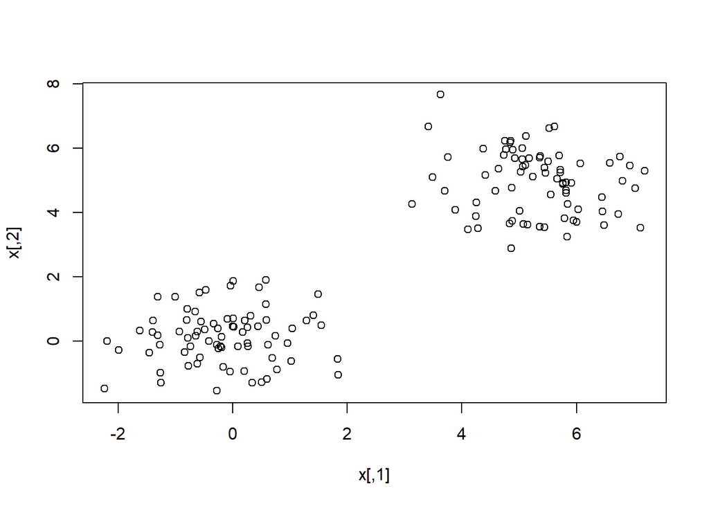

```r
x  <- rbind(x1,x2)
plot (x)
```

Com es pot comprovar les mostres estan clarament separades en dos grups. Si es vol complicar el problema es pot modificar els punts centrals (mean1 i mean2) fent que estiguin més propers i/o ampliar la variança (sigma) per a que les mostres estiguin més disperses.

A continuació anem aplicar l’algoritme kmeans amb 2, 4 i 8 clústers

```r
fit2       <- kmeans(x, 2)
y_cluster2 <- fit2$cluster

fit4       <- kmeans(x, 4)
y_cluster4 <- fit4$cluster

fit8       <- kmeans(x, 8)
y_cluster8 <- fit8$cluster
```

Les variables y_cluster2, y_cluster4 i y_cluster8 contenen per a cada mostra l’identificador del clúster a les que han estat assignades. Per exemple, en el cas dels k=2 les mostres s’han assignat al clúster 1 o al 2.

```r
y_cluster2
```

```
##   [1] 1 1 1 1 1 1 1 1 1 1 1 1 1 1 1 1 1 1 1 1 1 1 1 1 1 1 1 1 1 1 1 1 1 1 1 1 1
##  [38] 1 1 1 1 1 1 1 1 1 1 1 1 1 1 1 1 1 1 1 1 1 1 1 1 1 1 1 1 1 1 1 1 1 1 1 1 1
##  [75] 1 2 2 2 2 2 2 2 2 2 2 2 2 2 2 2 2 2 2 2 2 2 2 2 2 2 2 2 2 2 2 2 2 2 2 2 2
## [112] 2 2 2 2 2 2 2 2 2 2 2 2 2 2 2 2 2 2 2 2 2 2 2 2 2 2 2 2 2 2 2 2 2 2 2 2 2
## [149] 2 2
```

Per a visualitzar els clústers podem fer servir la funció clusplot. Mirem l’agrupació amb 2 clústers.

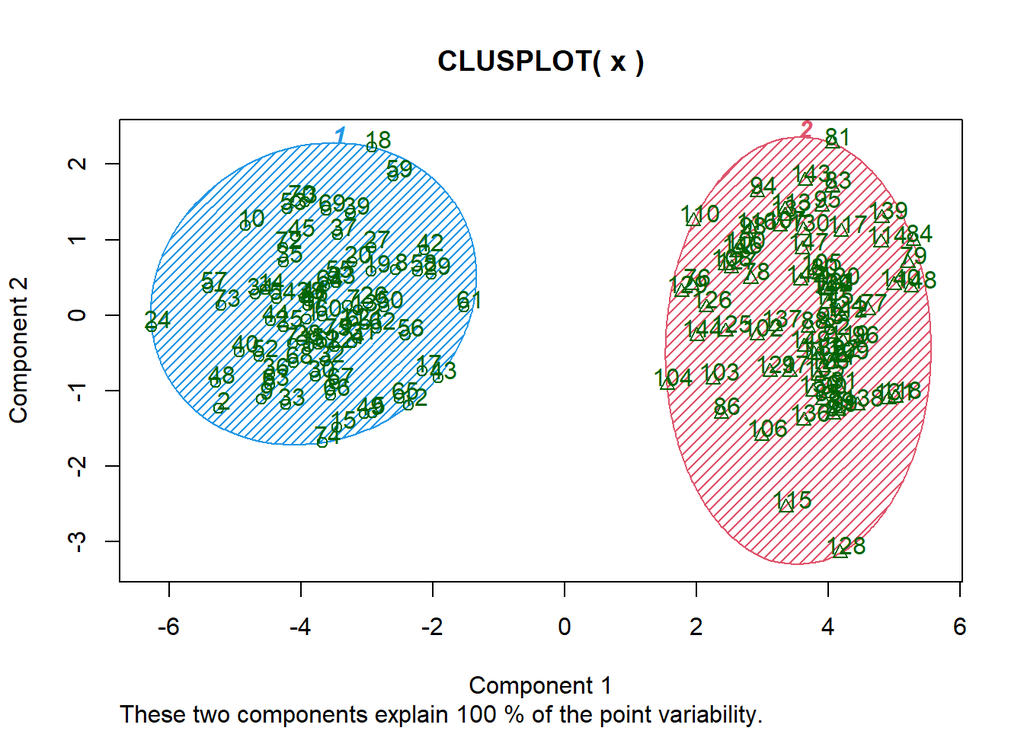

```r
clusplot(x, fit2$cluster, color=TRUE, shade=TRUE, labels=2, lines=0)
```

amb 4

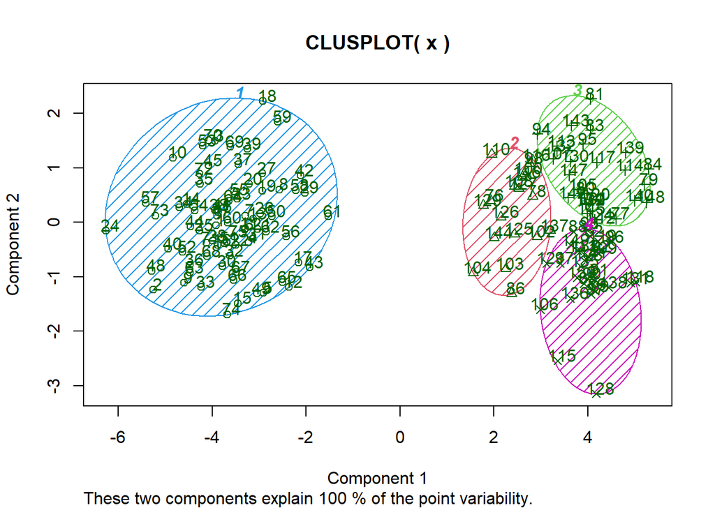

```r
clusplot(x, fit4$cluster, color=TRUE, shade=TRUE, labels=2, lines=0)
```

i amb 8

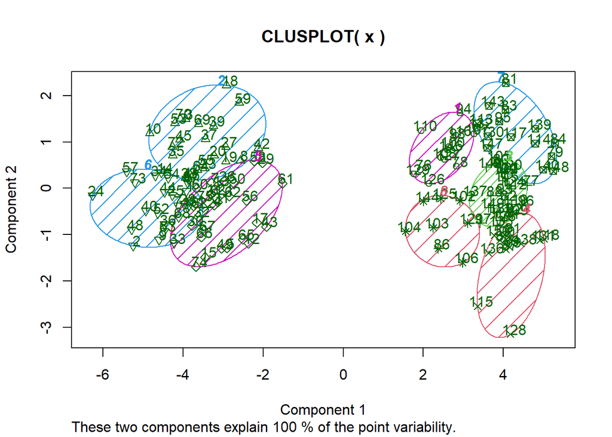

```r
clusplot(x, fit8$cluster, color=TRUE, shade=TRUE, labels=2, lines=0)
```

També podem visualitzar el resultat del procès d’agrupament amb el següent codi per al cas de 2 clústers

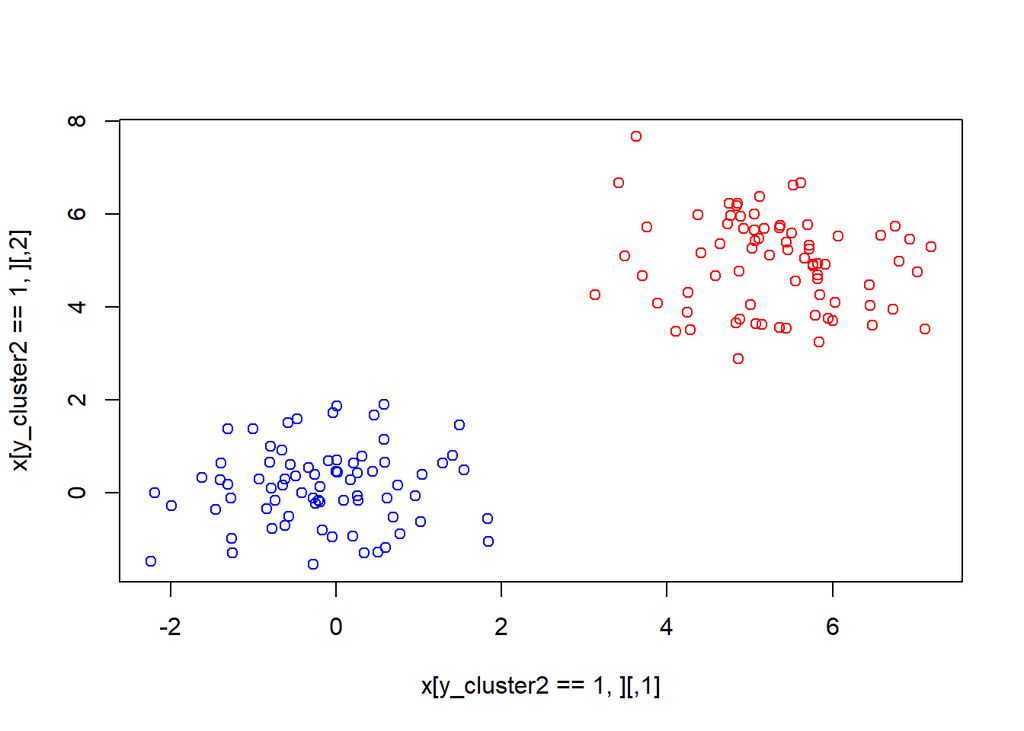

```r
plot(x[y_cluster2==1,],col='blue', xlim=c(min(x[,1]), max(x[,1])), ylim=c(min(x[,2]), max(x[,2])))
points(x[y_cluster2==2,],col='red')
```

per a 4

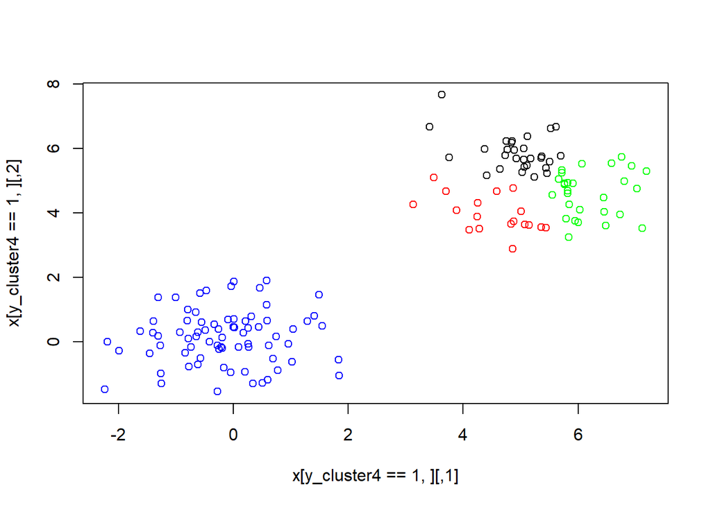

```r
plot(x[y_cluster4==1,],col='blue', xlim=c(min(x[,1]), max(x[,1])), ylim=c(min(x[,2]), max(x[,2])))
points(x[y_cluster4==2,],col='red')
points(x[y_cluster4==3,],col='green')
points(x[y_cluster4==4,],col='black')
```

i per a 8

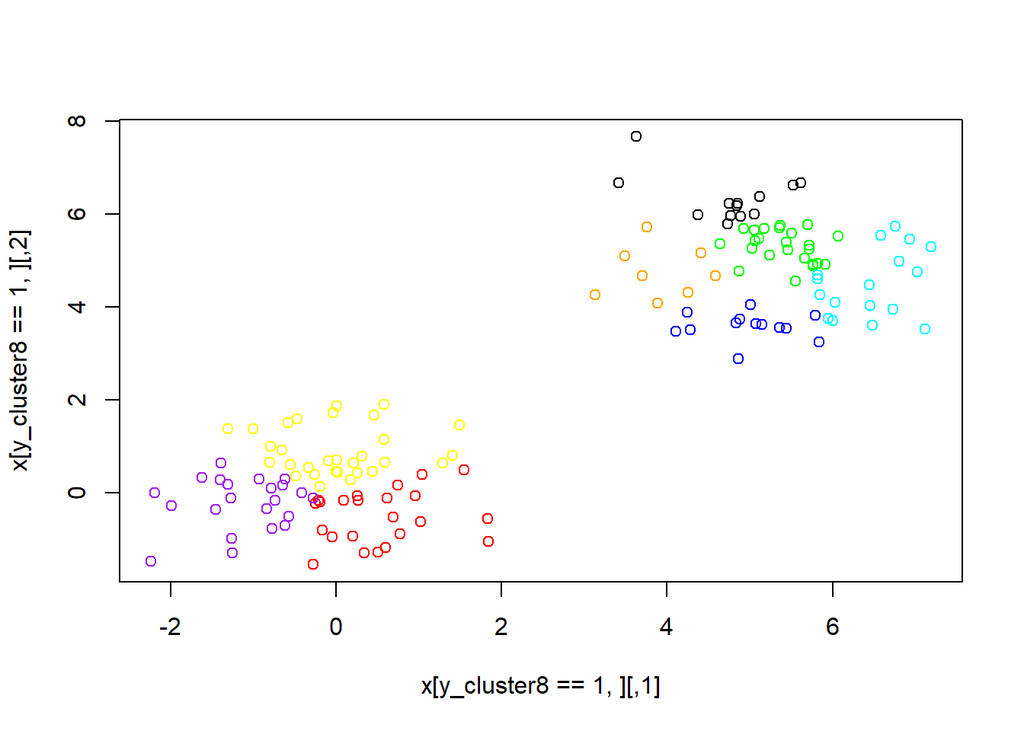

```r
plot(x[y_cluster8==1,],col='blue', xlim=c(min(x[,1]), max(x[,1])), ylim=c(min(x[,2]), max(x[,2])))
points(x[y_cluster8==2,],col='red')
points(x[y_cluster8==3,],col='green')
points(x[y_cluster8==4,],col='black')
points(x[y_cluster8==5,],col='yellow')
points(x[y_cluster8==6,],col='purple')
points(x[y_cluster8==7,],col='cyan')
points(x[y_cluster8==8,],col='orange')
```

Ara anem a avaluar la qualitat de l’agregació. Per això farem servir la funció silhouette que calcula la silueta de cada mostra

```r
d  <- daisy(x)
sk2 <- silhouette(y_cluster2, d)
sk4 <- silhouette(y_cluster4, d)
sk8 <- silhouette(y_cluster8, d)
```

La funció silhouette retorna per a cada mostra, el clúster on ha estat assignat, el clúster veí i el valor de la silueta. Així doncs, calculant la mitjana de la tercera columna podem obtenir una estimació de la qualitat de l’agrupament.

```r
mean(sk2[,3])
```

```
## [1] 0.7764157
```

```r
mean(sk4[,3])
```

```
## [1] 0.5718439
```

```r
mean(sk8[,3])
```

```
## [1] 0.3221964
```

Com es pot comprovar, agrupar en dos clústers es millor que en 4 o en 8, lo qual es lògic tenint en compte com s’han generat les dades.

# 3 Exemple 1.2

## 3.1 Mètodes d’agregació amb dades reals

A continuació anem a veure un altre exemple de com es fan servir els models d’agregació. Per això farem servir el fitxer iris.csv. Aquesta base de dades es troba descrita en https://archive.ics.uci.edu/ml/datasets/iris. Aquest dataset està prèviament treballat per tal de que les dades estiguin netes i sense errors. De no ser així hauriem de, abans de tot, buscar errors, valors nuls o outliers. Hauriem de mirar de discretitzar o eliminar columnes. I aquest últim pas repetir-ho varies vegades per tal de comprovar els resultats de les diferents execucions. De totes formes anem a visualitzar l’estructura i el resum de les dades.

```r
iris_data<-read.csv("http://archive.ics.uci.edu/ml/machine-learning-databases/iris/iris.data", header=T, sep=",")
attach(iris_data)
colnames(iris_data) <- c("sepalLength", "sepalWidth", "petalLength", "petalWidth", "class")
summary(iris_data)
```

```
##   sepalLength      sepalWidth     petalLength      petalWidth
##  Min.   :4.300   Min.   :2.000   Min.   :1.000   Min.   :0.100
##  1st Qu.:5.100   1st Qu.:2.800   1st Qu.:1.600   1st Qu.:0.300
##  Median :5.800   Median :3.000   Median :4.400   Median :1.300
##  Mean   :5.848   Mean   :3.051   Mean   :3.774   Mean   :1.205
##  3rd Qu.:6.400   3rd Qu.:3.300   3rd Qu.:5.100   3rd Qu.:1.800
##  Max.   :7.900   Max.   :4.400   Max.   :6.900   Max.   :2.500
##     class
##  Length:149
##  Class :character
##  Mode  :character
##
##
##
```

Com es pot comprovar, aquesta base de dades, està pensada per a problemes de classificació supervisada que volen classificar cada tipus de flor en un dels tipus existents (Iris-setosa, Iris-versicolor o Iris-virginica). Com en aquest exemple farem servir un mètode no supervisat, transformarem el problema supervisat original en un de no supervisat. Per aconseguir-ho no farem servir la columna class, que és la variable que es vol predir. Així doncs, intentarem trobar agrupacions fent servir únicament els quatre atributs que caracteritzen a cada flor.

Carreguem les dades i ens quedem únicament amb les quatre columnes que defineixen a cada flor

```r
x <- iris_data[,1:4]
```

Com inicialment no coneixem el número òptim de clústers, provem amb varis valors

```r
d <- daisy(x)
resultados <- rep(0, 10)
for (i in c(2,3,4,5,6,7,8,9,10))
{
  fit           <- kmeans(x, i)
  y_cluster     <- fit$cluster
  sk            <- silhouette(y_cluster, d)
  resultados[i] <- mean(sk[,3])
}
```

Mostrem en una gràfica els valors de la silueta mitja de cada prova per comprovar quin número de clusters és el millor

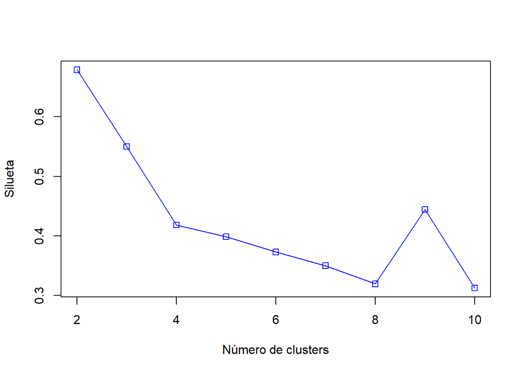

```r
plot(2:10,resultados[2:10],type="o",col="blue",pch=0,xlab="Número de clusters",ylab="Silueta")
```

Encara que el valor esperat es k=3, donat que el conjunt original té 3 classes, el millor valor que s’obten es k=2.

Un altre forma d’avaluar quin és el millor nombre de clústers és considerar el millor model, aquell que ofereix la menor suma dels quadrats de les distàncies dels punts de cada grup amb respecte al seu centre (withinss), amb la major separació entre centres de grups (betweenss). Com es pot comprovar és una idea conceptualment similar a la silueta. Una manera comuna de fer la sel.leció del nombre de clústers consisteix en aplicar el mètode elbow (colze), que no és més que la sel.leció del nombre de clústers en base a la inspecció de la gràfica que s’obten al iterar amb el mateix conjunt de dades per a distints valors del nombre de clústers. Es sel.leccionarà el valor que es troba en el colze de la corba.

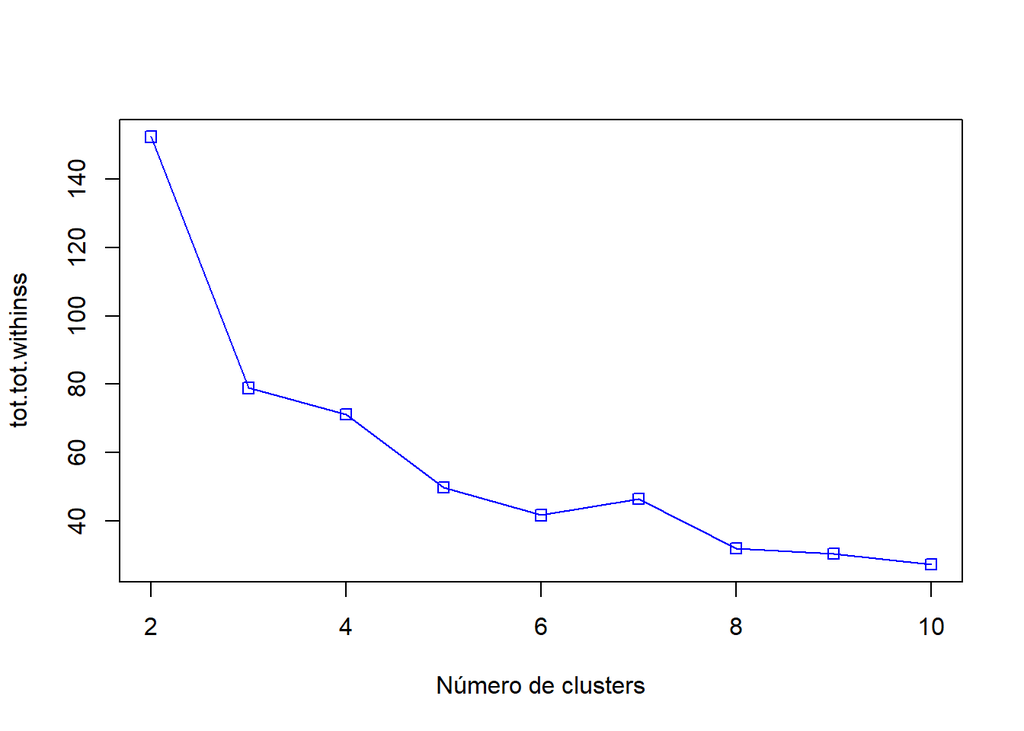

```r
resultados <- rep(0, 10)
for (i in c(2,3,4,5,6,7,8,9,10))
{
  fit           <- kmeans(x, i)
  resultados[i] <- fit$tot.withinss
}
plot(2:10,resultados[2:10],type="o",col="blue",pch=0,xlab="Número de clusters",ylab="tot.tot.withinss")
```